# 离散概率

Ryan Zhang

# 随机变量

- 随机变量(Random Variable)：
  - 是一个函数
  - 对事件进行概率值的赋值
- 离散随机变量：
  - 函数所能赋的值是可数的
- 连续随机变量：
  - 函数所能赋的值可以是某一区间内不可数的

# 概率质量函数

- 概率质量函数(Probability Mass Function,PMF): $p_{X}(x)=Pr(X=x)$
- 累积分布函数(Cumulative Distribution Function, CDF): $F_X(x)=Pr(X\leq x)$

# 期望、方差和标准差

- 期望： $\mathbb{E}[X]=\mu_X\\ =\Sigma_{i}{x_i}p_{X}(x_i)\\ =\Sigma_{i}{x_i}Pr(X=x_i)$
- 方差： $var(X)={\sigma_X^2}\\ =\Sigma_{i}(x_i-\mu_X)^2p_X(x_i)\\ =\Sigma_{i}(x_i-\mu_X)^2Pr(X=x_i)\\ =\Sigma_ix_i^2Pr(X=x_i)-{\mu_X}^2$
- 标准差： $SD(X)=\sqrt{(\sigma_X^2)}\\ =\sigma_X$

# 期望法则，期望、方差的性质

- 期望法则：
  - $X$是一个随机变量，$g(X)$是$X$的一个函数，则： $\mathbb{E}[g(X)]=\Sigma_ig(x_i)p_X(x_i)$
- $X$是一个随机变量，$Y=aX+b$是$X$的一个线性函数，则： $\mathbb{E}[Y]=a\mathbb{E}[X]+b$ $var(Y)=a^2\text{var}(X)$

# 伯努利过程

- 伯努利过程(Bernoulli Process):
  - 对同一实验的一系列独立试验
  - 实验只有两种结果：成功(1)或失败(0)
  - 每一次具体的试验，成功和失败的概率不变
  - 伯努利随机变量 $p_X{(k)}=\begin{cases}p,\qquad \qquad \text{if k = 1}\\1-p, \qquad \ \text{if k = 0}\end{cases}$

# 二项随机变量

- 二项随机变量(Binomial Random Variable):
  - 在一个n次试验的伯努利过程中，出现了x次成功的概率 $Pr(X=x)={n\choose x}p^x(1-p)^{n-x}\\ =\frac{n!}{(n-x)!x!}p^x(1-p)^{n-x}$ $\mathbb{E}[X]=\mu=np$ $var(X)=\sigma^2_X=npq$

# 二项随机变量

```r
dbinom(2,10,0.5)
```

```
## [1] 0.04394531
```

```r
factorial(10)/factorial(2)/factorial(8)*0.5^10
```

```
## [1] 0.04394531
```

# 二项随机变量

```r
pbinom(4,10,0.4)
```

```
## [1] 0.6331033
```

```r
sum(dbinom(0:4,10,0.4))
```

```
## [1] 0.6331033
```

```r
p <- 0
for (i in 0:4){p <- p + dbinom(i,10,0.4)}
p
```

```
## [1] 0.6331033
```

# 二项随机变量

```r
set.seed(123)
rbinom(20,1,0.5)
```

```
##  [1] 0 1 0 1 1 0 1 1 1 0 1 0 1 1 0 1 0 0 0 1
```

# 蒙特卡洛模拟

- 蒙特卡洛模拟(Monte Carlo Simulation):

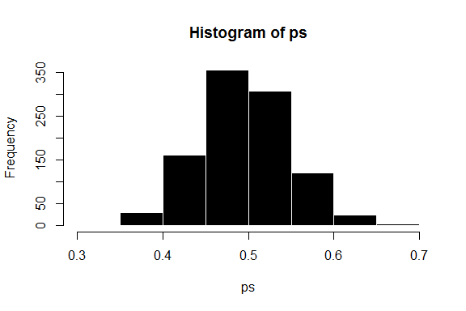

```r
set.seed(0306)
ps <- vector()
for (i in 1:999){
    ps <- c(ps, table(rbinom(100,1,0.5))[2]/100)
}
hist(ps, border = 0, col = "black")
```